# Network centrality

The following notebook will demonstrate how directed weighted graphs can be constructed from word association data. The weights reflect the proportion of people that give a response to each cue word (we’ll cover alternatives in the similarityDemo).

We’ll use this network to illustrate different ways in which nodes can be *central*. Over [403 network centrality measures](https://www.centiserver.org/) are currently available and the list keeps growing (Jalili et al. 2015). We’ll focus on the most commonly used ones and consider versions that are useful for directed weighted graphs.

# Load network

For this example, we will use the USF network (Nelson, McEvoy, and Schreiber 2004) as some centrality measures take a long time to compute on larger graphs like SWOW (> 10,000 nodes).

```r
load('../data/WAT/USF.rda') %>% as_tibble()
```

| value |
| --- |
| USF |

```r
X = USF
DT::datatable(X %>% filter(cue=='island'))
```

|  | cue | response | R1 | n | R1.Strength |
| --- | --- | --- | --- | --- | --- |
| 1 | island | alone | 2 | 100 | 0.02 |
| 2 | island | Bahamas | 1 | 100 | 0.01 |
| 3 | island | bay | 1 | 100 | 0.01 |
| 4 | island | beach | 7 | 100 | 0.07 |
| 5 | island | coconuts | 1 | 100 | 0.01 |
| 6 | island | continent | 1 | 100 | 0.01 |
| 7 | island | desert | 1 | 100 | 0.01 |
| 8 | island | deserted | 3 | 100 | 0.03 |
| 9 | island | fantasy | 1 | 100 | 0.01 |
| 10 | island | gilligan's | 3 | 100 | 0.03 |

[output cut: 24 more lines]

Many studies remove idiosyncratic responses, that is, response generated by a single participant. For the example *island*, there are 18 responses given only once out of 34. Given that most response distributions have a heavy tail, this large number of idiosyncratic responses is entirely expected. Furthermore, as you can judge yourself, they are far from arbitrary. For this reason, it often makes sense to include them and avoid any additional researcher degree’s of freedom.

To build a graph, all we need is a table where each row defines an edge based on a source (cue) and (target), together with an optional weight (R1.Strength). Before we proceed, we need to make sure the graph is simple (i.e. it does not contain any loops).

The adjacency matrix is a different representation of a graph where each row and column corresponds to a node, and the cells represent the absence or presence of an edge. In this case, these cells are values between 0 and 1 suggesting a *weighted* adjacency matrix.

```r
G[c('island','sun','tropical','vacation','fern','office'),
  c('island','sun','tropical','vacation','fern','office')]
```

```
6 x 6 sparse Matrix of class "dgCMatrix"
         island  sun tropical vacation fern office
island     .    0.08     0.08     0.03    .      .
sun        .    .        .        .       .      .
tropical   0.18 0.04     .        .       .      .
vacation   0.01 0.01     .        .       .      .
fern       .    .        .        .       .      .
office     .    .        .        .       .      .
```

In some cases, participants did respond with the same word as the cue word, so these are removed.

## Graph connectedness

### Graph components

A related idea is that of **graph components**. A component of a graph associated with a node $v_i$ is the maximal connected induced subgraph containing all nodes that are connected to $v_i$. In directed graphs, the *weakly connected component* does not consider whether an edge is in- or out-going, whereas the *strongly connected component* requires that all nodes in the component are connected through in- and out-going edges. Finally, the *largest connected component* is the induced subgraph which contains the maximum number of nodes.

### Coverage

Extracting the strongest component means each word has at least one in- and out-going link $k_{in} \geq 1, k_{out} \geq 1$. This implies that only a subset of response words is retained, namely those that are in the list of cues that occur at least once in the list of responses. It is important to reflect on what this censoring means when calculating different types of centrality estimates.

```r
X %<>% mutate(isCue = ifelse(response %in% X$cue,1,0))

X.cover = X %>% filter(isCue ==1) %>%
  group_by(cue) %>%
  summarise(coverage = sum(R1.Strength))

DT::datatable(X.cover)
```

|  | cue | coverage |
| --- | --- | --- |
| 1 | Advil | 0.9400000000000001 |
| 2 | Africa | 0.8 |
| 3 | America | 0.9500000000000001 |
| 4 | American | 0.9 |
| 5 | Asia | 0.87 |
| 6 | Band-Aid | 0.88 |
| 7 | Britannica | 0.94 |
| 8 | California | 0.75 |
| 9 | Celsius | 0.44 |
| 10 | Cheddar | 0.99 |

[output cut: 4917 more lines]

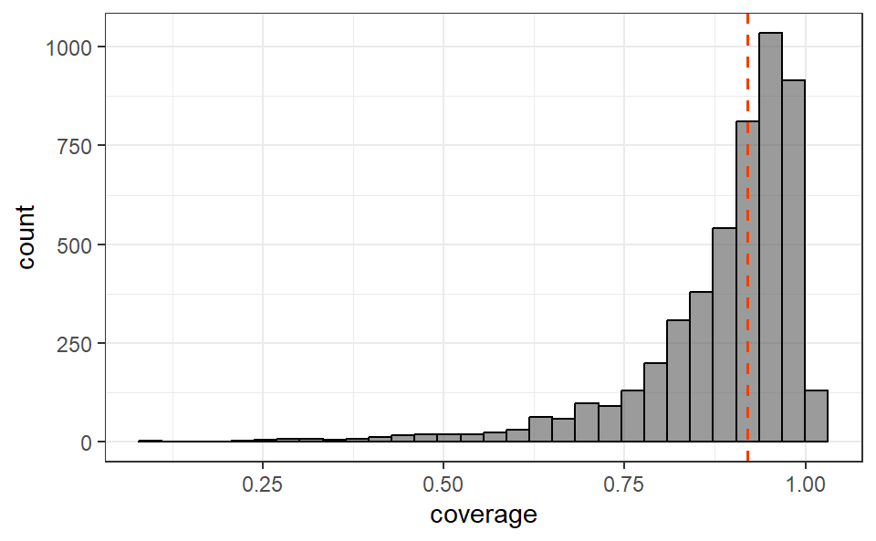

```r
fig.coverage = ggplot(X.cover, aes(x = coverage)) +
  geom_histogram(color = 'black',bins = 30,alpha = 0.6) +
  geom_vline(xintercept = median(X.cover$coverage), linetype="dashed",
                color = "orangered2", size=0.7) +
  theme_bw()

print(fig.coverage)
```

## Macro-level descriptives

The macro-level descriptives provide information about the number of nodes and edges, the density of the network and the diameter.

```r
S.global = list()
S.global$nEdges = ecount(G)
S.global$nNodes = vcount(G)
S.global$density = edge_density(G)
S.global$diameterPath = get_diameter(G)

#S.global$diameter = diameter(G, weights = NULL) # weighted diameter or length of the longest geodesic (i.e shortest path)

S.global$cc = transitivity(G,'global') # global clustering coefficient

#print.simple.list(S.global)
```

The network consists of 4875 nodes and 111965 edges. The density of the network is 0.0047122 and the overal transitivity, that is the probability that neighbors of nodes are connected (also referred to as the clustering coefficient is) 0.070881. In this network the longest path has a length of 8:  
quench -> loose -> wide -> spread -> shed -> lizard -> alligator -> crocodile.

## Local centrality measures

Local centrality measures considers how a node is connected with its direct neighbors. This includes measures such as the number of incoming edges (`in-degree` $k_{in}$), the number of outgoing edges (`out-degree` $k_{out}) and weighted versions of these measures (*strength*).

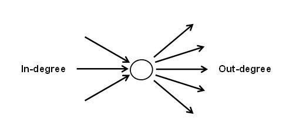

Illustration of in and out-degree

```r
ct_k = tibble(names  = vlabels,
                    degree_in = igraph::degree(G, mode = 'in'),
                    degree_out = igraph::degree(G, mode = 'out'),
                    strength_in = igraph::strength(G,mode = 'in'),
                    strength_out = igraph::strength(G, mode = 'out'))

DT::datatable(ct_k)
```

|  | names | degree_in | degree_out | strength_in | strength_out |
| --- | --- | --- | --- | --- | --- |
| 1 | a | 10 | 22 | 0.624159402595317 | 0.9999999999999996 |
| 2 | aardvark | 1 | 20 | 0.1063829787234042 | 1 |
| 3 | abdomen | 1 | 18 | 0.03157894736842104 | 0.9999999999999999 |
| 4 | abduct | 2 | 12 | 0.1478558665872543 | 1 |
| 5 | ability | 31 | 36 | 1.629618266056651 | 0.9999999999999992 |
| 6 | able | 24 | 15 | 1.378969620231766 | 0.9999999999999998 |
| 7 | abnormal | 24 | 26 | 0.7971735973699132 | 0.9999999999999999 |
| 8 | above | 30 | 12 | 1.475082523565899 | 0.9999999999999996 |
| 9 | absence | 5 | 32 | 0.2876412293844852 | 0.9999999999999994 |
| 10 | absent | 14 | 22 | 0.4552148662357157 | 0.9999999999999998 |

[output cut: 4865 more lines]

Not surprisingly, the out-strength is the same for each node. This is because the summed associative strengths for each node are normalized to sum to one.

## Global centrality measures

In contrast to local centrality measures which only count the number and the strength of a node and its direct neighbors, *global* centrality measures consider the centrality of the neighbors as well to determine how central a node $v_i$ is. There are hundreds of ways of calculating centrality, resulting in highly related measures that capture slightly different aspects about what nodes are important.

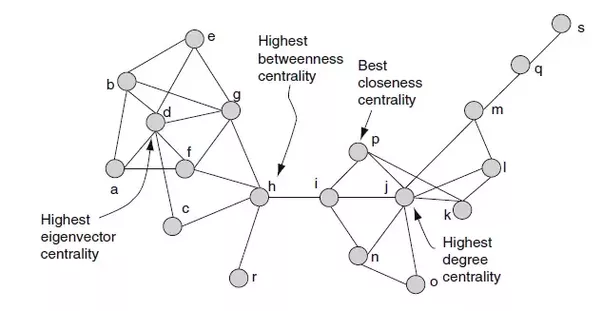

Illustration of various centrality measures

## Neighborhood size

One idea is to consider the neighbors of neighbors in calculating degree and strength.

```r
ct_nb = tibble(names = vlabels,
                nb3_out = igraph::neighborhood.size(G,order = 3, mode = 'out'),
                nb3_in = igraph::neighborhood.size(G,order = 3, mode = 'in'),
                nb2_out = igraph::neighborhood.size(G,order = 2, mode = 'out'),
                nb2_in = igraph::neighborhood.size(G,order = 2, mode = 'in'))

DT::datatable(cbind(ct_nb$names,round(ct_nb %>% select(-names),5)))
```

|  | ct_nb$names | nb3_out | nb3_in | nb2_out | nb2_in |
| --- | --- | --- | --- | --- | --- |
| 1 | a | 2732 | 3025 | 403 | 208 |
| 2 | aardvark | 2560 | 35 | 365 | 4 |
| 3 | abdomen | 2511 | 926 | 335 | 36 |
| 4 | abduct | 2232 | 205 | 268 | 14 |
| 5 | ability | 3272 | 4037 | 624 | 535 |
| 6 | able | 2396 | 3217 | 285 | 302 |
| 7 | abnormal | 2703 | 3277 | 406 | 342 |
| 8 | above | 2113 | 4599 | 239 | 772 |
| 9 | absence | 3158 | 537 | 567 | 35 |
| 10 | absent | 2528 | 3861 | 353 | 389 |

[output cut: 4865 more lines]

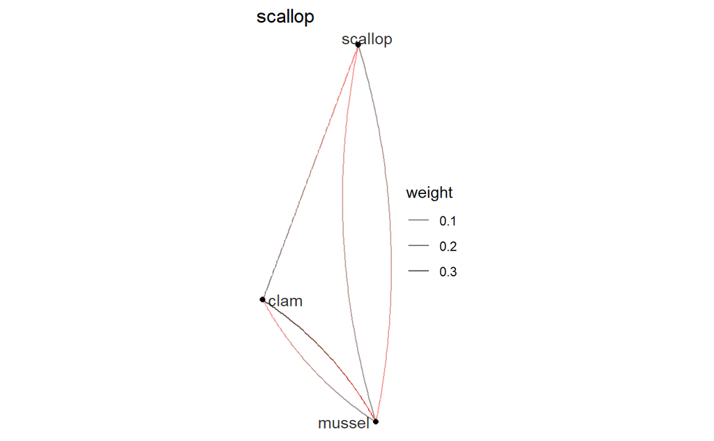

## PageRank and EigenCentrality

```r
ct_pr = tibble(names = vlabels,
        pr_1 = igraph::page_rank(G,directed = TRUE,damping = 0.1)$vector,
        pr_20 = igraph::page_rank(G,directed = TRUE,damping = 0.2)$vector,
        pr_50 = igraph::page_rank(G,directed = TRUE,damping = 0.5)$vector,
        pr_70 = igraph::page_rank(G,directed = TRUE,damping = 0.7)$vector,
        eigen = igraph::eigen_centrality(G,directed = TRUE,scale = TRUE)$vector)
```

|  | ct_pr$names | pr_1 | pr_20 | pr_50 | pr_70 | eigen |
| --- | --- | --- | --- | --- | --- | --- |
| 1 | a | 0.0002 | 0.0002 | 0.0002 | 0.0002 | 0.0049 |
| 2 | aardvark | 0.0002 | 0.0002 | 0.0001 | 0.0001 | 0 |
| 3 | abdomen | 0.0002 | 0.0002 | 0.0001 | 0.0001 | 0.0005 |
| 4 | abduct | 0.0002 | 0.0002 | 0.0001 | 0.0001 | 0 |
| 5 | ability | 0.0002 | 0.0002 | 0.0002 | 0.0002 | 0.0028 |
| 6 | able | 0.0002 | 0.0002 | 0.0002 | 0.0002 | 0.0033 |
| 7 | abnormal | 0.0002 | 0.0002 | 0.0002 | 0.0002 | 0.0056 |
| 8 | above | 0.0002 | 0.0002 | 0.0003 | 0.0004 | 0.0469 |
| 9 | absence | 0.0002 | 0.0002 | 0.0001 | 0.0001 | 0.0001 |
| 10 | absent | 0.0002 | 0.0002 | 0.0002 | 0.0001 | 0.0102 |

[output cut: 4865 more lines]

Let’s explore where the differences are situated by plotting extreme cases.

```r
X.ct = left_join(ct_k,ct_pr,by = 'names')
m_ct1 = lm(strength_in ~ pr_1,data = X.ct)
m_ct70 = lm(strength_in ~ pr_70,data = X.ct)
X.ct$cooks1 = cooks.distance(m_ct1)
X.ct$cooks70 = cooks.distance(m_ct70)
outlier1 = X.ct %>% slice_max(n = 30,order_by = abs(cooks1))
outlier70 = X.ct %>% slice_max(n = 30,order_by = abs(cooks70))

fig.pr1 = ggplot(X.ct,aes(x = strength_in,y = pr_1)) +
  geom_point(size = 0.3,alpha = 0.3,colour = '#DD4814') +
  geom_smooth(method = "lm", formula= y ~ x, se = FALSE,color = 'grey',size = 0.5) +
  geom_text_repel(data = X.ct %>% filter(names %in% outlier1$names),
                  aes(label = names),segment.color = '#DD4814',segment.alpha=0.5,max.overlaps = 200) +
  theme(aspect.ratio=1) + ggtitle('PageRank centrality alpha = 0.01')  + theme_bw()

fig.pr70 = ggplot(X.ct,aes(x = strength_in,y = pr_70)) +
  geom_point(size = 0.3,alpha = 0.3,colour = '#DD4814') +
  geom_smooth(method = "lm", formula= y ~ x, se = FALSE,color = 'grey',size = 0.5) +
  geom_text_repel(data = X.ct %>% filter(names %in% outlier70$names),
                  aes(label = names),segment.color = '#DD4814',segment.alpha=0.5,max.overlaps = 200) +
  theme(aspect.ratio=1) + ggtitle('PageRank centrality alpha = 0.70') + theme_bw()



# The following code might give you a memory error if used with large graphs...
#m_ct = lm(strength_in ~ eigen,data = X.ct)
#X.ct$cooks = cooks.distance(m_ct)
#outlier = X.ct %>% slice_max(n = 30,order_by = abs(cooks))


# fig.eig = ggplot(X.ct,aes(x = strength_in,y = eigen)) +
#   geom_point(size = 0.3,alpha = 0.3,colour = '#DD4814') +
#   geom_smooth(method = "lm", formula= y ~ x, se = FALSE,color = 'grey',size = 0.5) +
#   geom_text_repel(data = X.ct %>% filter(names %in% outlier$names),
#                   aes(label = names),segment.color = '#DD4814',segment.alpha=0.5,max.overlaps = 200) +
#   theme(aspect.ratio=1) +
#   ggtitle('Eigencentrality')
```

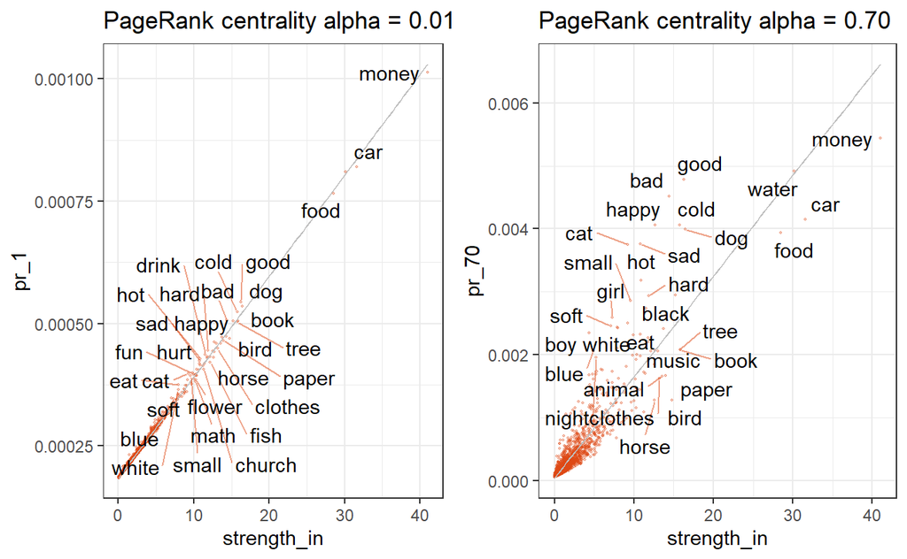

The outliers with higher PageRank emphasizes adjectives (good,bad,cold) at the expense of concrete nouns (money, food, car, book). The results for Eigencentrality are harder to interpret.

## Betweenness

Another class of centrality measures is based on the number of shortest paths a nodes lies. A widely used path-based measures are *betweenness*. According to the igraph documentation for betweenness: *The vertex and edge betweenness are (roughly) defined by the number of geodesics (shortest paths) going through a vertex or an edge.*

```r
# Both betweenness for directed and undirected paths are considered
ct_b = tibble(names = vlabels,
          betweenness = igraph::betweenness(G,directed = TRUE,normalized = T),
          betweennessU = igraph::betweenness(G,directed = FALSE,normalized = T)
        )
```

|  | ct_b$names | betweenness | betweennessU |
| --- | --- | --- | --- |
| 1 | a | 0 | 0 |
| 2 | aardvark | 0 | 4e-05 |
| 3 | abdomen | 0 | 3e-05 |
| 4 | abduct | 1e-05 | 1e-05 |
| 5 | ability | 0.00082 | 0.00011 |
| 6 | able | 0.0001 | 5e-05 |
| 7 | abnormal | 0.00096 | 0.00055 |
| 8 | above | 0.00085 | 0.00037 |
| 9 | absence | 8e-05 | 0.00014 |
| 10 | absent | 0.00026 | 0.00015 |

[output cut: 4865 more lines]

Compare the top 10 for directed and undirected versions of betweenness. What are the implications?

Is there a qualitative pattern to words where betweenness and in-strength are less related?

```r
X.ct = left_join(ct_nb,ct_k,by = 'names') %>% left_join(.,ct_pr,by = 'names') %>% left_join(.,ct_b,by ='names')
m_ct = lm(strength_in ~ betweenness,data = X.ct)
X.ct$cooks = cooks.distance(m_ct)

outlier = X.ct %>% slice_max(n = 40,order_by = abs(cooks))

fig.betw1 = ggplot(X.ct,aes(x = strength_in,y = betweenness)) +
  geom_point(size = 0.3,alpha = 0.3,colour = '#DD4814') +
  geom_smooth(method = "lm", formula= y ~ x, se = FALSE,color = 'grey',size = 0.5) +
  geom_text_repel(data = X.ct %>% filter(names %in% outlier$names),
                  aes(label = names),segment.color = '#DD4814',segment.alpha=0.5,max.overlaps = 100,size =3) +
  theme(aspect.ratio=1) +
  ggtitle('Betweenness') + theme_bw()

# Let's zoom in on the low range
outlier = X.ct %>% filter(strength_in < 5) %>%  slice_max(n = 40,order_by = abs(cooks))

fig.betw2 = ggplot(X.ct %>% filter(strength_in<5),aes(x = strength_in,y = betweenness)) +
  geom_point(size = 0.3,alpha = 0.3,colour = '#DD4814') +
  geom_smooth(method = "lm", formula= y ~ x, se = FALSE,color = 'grey',size = 0.5) +
  geom_text_repel(data = X.ct %>% filter(names %in% outlier$names),
                  aes(label = names),segment.color = '#DD4814',segment.alpha=0.5,max.overlaps = 100,size = 3) +
  theme(aspect.ratio=1) + ggtitle('Betweenness (Zoom)') + theme_bw()
```

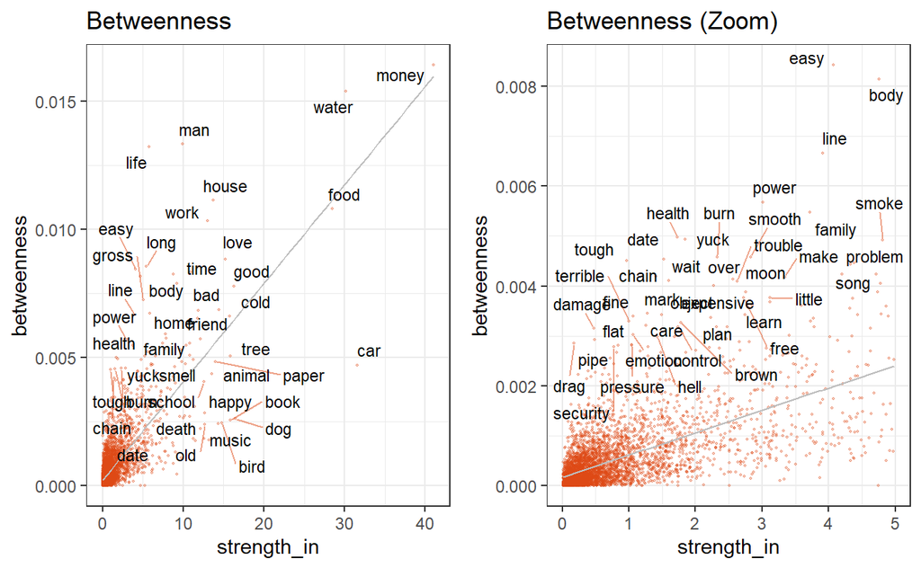

# Clustering measures

A somewhat different measure capture the degree of clustering of a node. Most natural networks are strongly clustered. The local clustering coefficient captures the transitivity between triples of nodes. For example, in a social network this transitivity would indicate that your friends might also be friends among themselves. More precisely, the local clustering coefficient $C_{i}$ for a vertex $v_{i}$ represents a proportion of the number of links between the vertices within its neighborhood divided by the number of links that could possibly exist between them.

Things quickly get complicated in weighted and directed graphs, and in practice clustering coefficients are not very robust.

```r
z = igraph::transitivity(G,type = 'localundirected',isolates = 'zero')
ct_cc = tibble(names = vlabels,
               transitivity = z,
               cc = igraph::transitivity(simplify(G),type = 'barrat',isolates = 'zero'))
X.ct = left_join(X.ct,ct_cc,by = 'names')
```

Let’s illustrate with two extreme example with a low (*pumpkin*) and high (*orchid*) clustering coefficient.

```r
v.cc.low = 'pumpkin'; v.cc.high = 'orchid'

G.cc.low = extractEgoGraph(G %>% as_tbl_graph(),v = v.cc.low,0.01)
G.cc.high = extractEgoGraph(G %>% as_tbl_graph(),v = v.cc.high,0.01)

# change geom_edge_link to geom_edge_fan0 to visualize directed edges
fig.cc.low = ggraph(G.cc.low,layout = 'igraph', algorithm = 'graphopt') +
  geom_edge_link(aes(alpha = weight)) +
  geom_node_point() +
  geom_node_text(aes(label = name),repel=T) +
  scale_edge_alpha(range = c(0.15,0.3)) +
  theme_void() +
  coord_fixed() +
  ggtitle(v.cc.low)

fig.cc.high = ggraph(G.cc.high,layout = 'igraph', algorithm = 'fr') +
  geom_edge_link(aes(alpha = weight)) +
  geom_node_point() +
  geom_node_text(aes(label = name),repel=T) +
  scale_edge_alpha(range = c(0.15,0.3)) +
  theme_void() +
  coord_fixed() +
  ggtitle(v.cc.high)
```

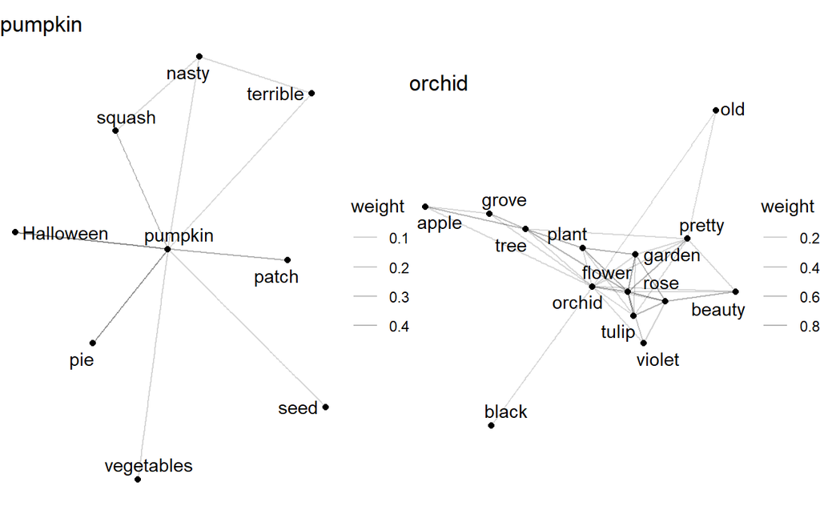

# Evaluation

## Concreteness

Concreteness effects refer to an advantage in processing concrete over abstract words and this advantage has been attributed a wide range of factors. One explanation is that concrete words have higher contextual availability than abstract words (Schwanenflugel and Shoben 1983). According to this view, abstract words have a stronger dependence on context. Other studies have that the advantage of concrete words could be due to the number-of-features. Either way, it seems that distinct distributional factors could contribute and below we test whether different types of centrality are associated with concreteness.

We’ll make use of the Brysbaert, Warriner, and Kuperman (2014) concreteness ratings for a large set of English words.

```r
file.concreteness = '../data/concreteness/english.concreteness.Brysbaert2016.csv'
X.con = readr::read_delim(file.concreteness,delim = '\t')
X.con = inner_join(X.ct,X.con,by = c('names'= 'Word'))

rs  = corrTable(X.con %>% select(-names,-Dom_Pos),rmethod='spearman',absolute = TRUE)

fig.conc = ggplot(rs %>% filter(var1 =='Conc.M',
                         var2 %in% c('nb2_out','nb3_out','degree_out','transitivity','betweenness','betweennessU',
                                                     'pr_1','pr_70','strength_in','cc','SUBTLEX')),
           aes(x=reorder(var2, var2, function(x) length(x)), y=r)) +
        geom_bar(stat="identity", aes(fill = sign), alpha = 0.4) +
        scale_fill_manual(values=c("blue", "red")) +
        geom_errorbar(aes(ymin=cl, ymax=cu), width=.2)  + theme_bw() + xlab('Centrality Measure') +
        theme(axis.text.x = element_text(angle = 45, hjust = 1))
```

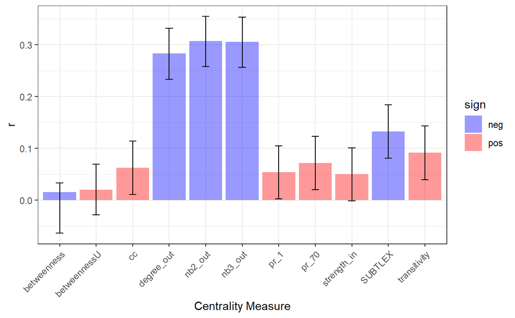

## Semantic Richness effects

Words that are semantically rich have processing advantage (e.g. shorter RTs across a range of lexical tasks). There are many ways in which semantic richness can be derived. This could be a matter of number of shared features, number of distinct features, contextual dispersion, number of semantic neighbors, number of senses, and so on (e.g. Pexman et al. 2017). Some of these measures reflect the way features are counted, and potentially a further distinction can be drawn based on *local* and *global* measures of centrality, such as degree measures based on direct or indirect neighbors.

```r
# Load Calgary Semantic Decision Project Data
file.CSD = '../data/CalgarySemanticDecision/CalgarySemanticDecisionSummary.csv'
X.csdp = read_csv(file.CSD)
X.csdp %<>% select(word,wordType,RT = zRTclean_mean,accuracy = ACC,concreteRating)

X.csdp = inner_join(X.csdp,X.ct,by = c('word' = 'names')) %>% filter(complete.cases(.))
DT::datatable(as.data.frame(round(cor(X.csdp %>% select(-word,-wordType),method = 'spearman')[,c('RT','accuracy','concreteRating')],3)))
```

|  | RT | accuracy | concreteRating |
| --- | --- | --- | --- |
| RT | 1 | -0.632 | -0.566 |
| accuracy | -0.632 | 1 | 0.378 |
| concreteRating | -0.566 | 0.378 | 1 |
| nb3_out | 0.225 | -0.163 | -0.381 |
| nb3_in | -0.219 | 0.042 | -0.011 |
| nb2_out | 0.216 | -0.144 | -0.392 |
| nb2_in | -0.204 | 0.036 | -0.038 |
| degree_in | -0.211 | 0.05 | -0.035 |
| degree_out | 0.17 | -0.113 | -0.357 |
| strength_in | -0.254 | 0.084 | 0.054 |

[output cut: 11 more lines]

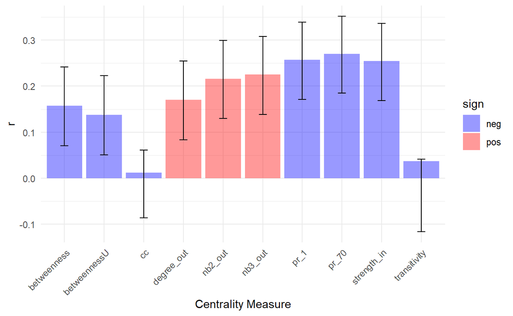

Let’s see how this compares to other types of predictors taken from the English Crowdsourcing Project (ECP) word prevalence data

```r
# Correct the skew in nb2_in
m.csdp = lm(RT ~ log(nb2_in+1) + (nb2_out), data = X.csdp)
print(summary(m.csdp))
```

```
Call:
lm(formula = RT ~ log(nb2_in + 1) + (nb2_out), data = X.csdp)

Residuals:
     Min       1Q   Median       3Q      Max
-0.91462 -0.27346 -0.02088  0.24002  1.70401

Coefficients:
                   Estimate  Std. Error t value            Pr(>|t|)
(Intercept)     -0.02126511  0.04974107  -0.428               0.669
log(nb2_in + 1) -0.08627124  0.00830498 -10.388 <0.0000000000000002 ***
nb2_out          0.00060671  0.00006982   8.690 <0.0000000000000002 ***
---
Signif. codes:  0 ‘***’ 0.001 ‘**’ 0.01 ‘*’ 0.05 ‘.’ 0.1 ‘ ’ 1

Residual standard error: 0.3793 on 1491 degrees of freedom
Multiple R-squared:  0.09958,   Adjusted R-squared:  0.09837
F-statistic: 82.45 on 2 and 1491 DF,  p-value: < 0.00000000000000022
```

Finally, let’s take at the Mandera, Keuleers, and Brysbaert (2020) English Word Prevalence RT data. These RTs measure how long it takes for participants to judge whether they “know” a word.

```r
file.prevalence = '../data/EnglishLexiconProject/ELPzScores.csv'
X.ecd = read_csv(file.prevalence)
X.ecd  %<>% select(word = Word,
                    length = Length,
                    ON = Ortho_N,prevalence = Prevalence,
                    ECP_RT,
                    zRT = zECP_24,
                    WF = SubtlexZipf)

X.csdp2 = inner_join(X.csdp,X.ecd,by ='word')

rs.ecd  = corrTable(X.csdp2 %>% select(-word,-wordType),
                    rmethod='spearman',absolute = TRUE)

fig.ecd = ggplot(rs.ecd %>% filter(var1 =='zRT',
             var2 %in% c('degree_out','cc','betweenness','betweennessU',
                         'eigen','pr_70','strength_in','WF')),
           aes(x=reorder(var2, var2, function(x) length(x)), y=r)) +
        geom_bar(stat="identity", aes(fill = sign), alpha = 0.5) +
        scale_fill_manual(values=c("blue", "red")) +
        geom_errorbar(aes(ymin=cl, ymax=cu), width=.2)  +
        theme_minimal() +
        xlab('Centrality Measure') +
        theme(axis.text.x = element_text(angle = 45,hjust = 1))
```

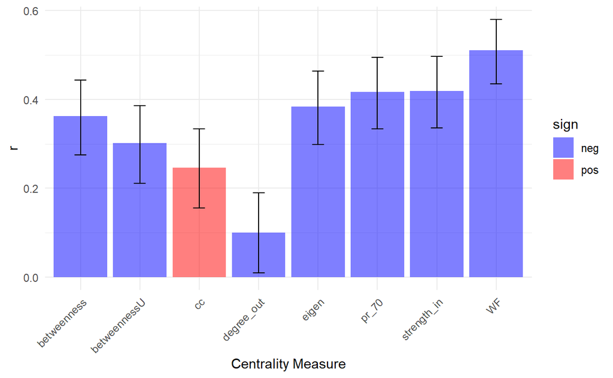

# Exercises

- There are many centrality values and its far from obvious which one is best to use. One criterion could be the robustness of the measure. Calculate the centrality for the `EAT` and `Sw.en` networks as well and correlate the centrality across these three networks. How certain are you that the values are comparable? What factors play a role? Why are certain measures more robust than others?
- So far we have used associative strength to construct weighted networks. What do you expect for `PPMI` or `RW` networks? Hint: Think about the type of semantic relations and the density of the graph.

# Further reading

A great resource for network analysis in R is the [Introduction to R for networks](https://kateto.net/wp-content/uploads/2016/01/NetSciX_2016_Workshop.pdf) page by Katherine Ongnayanova. It will provide you with a refresher of basic R knowledge and builds up your skills to work with `igraph`.

# References

Brysbaert, Marc, Amy Beth Warriner, and Victor Kuperman. 2014. “Concreteness Ratings for 40 Thousand Generally Known English Word Lemmas.” *Behavior Research Methods* 46 (3): 904–11.

Jalili, Mahdi, Ali Salehzadeh-Yazdi, Yazdan Asgari, Seyed Shahriar Arab, Marjan Yaghmaie, Ardeshir Ghavamzadeh, and Kamran Alimoghaddam. 2015. “CentiServer: A Comprehensive Resource, Web-Based Application and r Package for Centrality Analysis.” *PloS One* 10 (11): e0143111.

Mandera, Paweł, Emmanuel Keuleers, and Marc Brysbaert. 2020. “Recognition Times for 62 Thousand English Words: Data from the English Crowdsourcing Project.” *Behavior Research Methods* 52 (2): 741–60.

Nelson, Douglas L, Cathy L McEvoy, and Thomas A Schreiber. 2004. “The University of South Florida Free Association, Rhyme, and Word Fragment Norms.” *Behavior Research Methods, Instruments, and Computers* 36: 402–7. https://doi.org/10.3758/bf03195588.

Pexman, Penny M, Alison Heard, Ellen Lloyd, and Melvin J Yap. 2017. “The Calgary Semantic Decision Project: Concrete/Abstract Decision Data for 10,000 English Words.” *Behavior Research Methods* 49 (2): 407–17.

Robinson, Maria M, Isabella C DeStefano, Edward Vul, and Timothy F Brady. 2023. “Local but Not Global Graph Theoretic Measures of Semantic Networks Generalize Across Tasks.” *Behavior Research Methods*, 1–30.

Schwanenflugel, Paula J, and Edward J Shoben. 1983. “Differential Context Effects in the Comprehension of Abstract and Concrete Verbal Materials.” *Journal of Experimental Psychology: Learning, Memory, and Cognition* 9 (1): 82.